# Regression with neural network in keras

# 1 Objective/Overview

The objective of this project is to use neural network with keras to solve regression problem in Python and R. This project was originally done in Python in *Deep Learning with Keras*, from Antonio Gulli and Sujit Pal, Keras regression example - predicting benzene levels in the air. Here we do this project in R.

This section executes blue part of the project flow shown in the figure below in R.

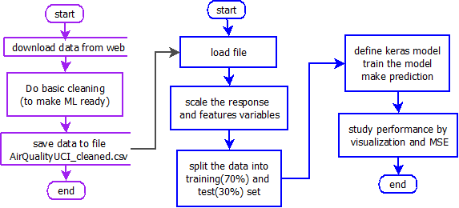

- In previous section we downloaded the data from web and did some basic cleaning.
- In this section, we do the following
- Load the data which was processed in previous section
- Scale the variables (response and features)
- Split the sample in 70-30 for training and testing
- Define the model with one hidden layer and one output layer. The output layer has no activation function because it is regression problem.
- Run the model and predict for testing
- Meausre the performance with MSE and some visualization

## 1.1 Links

Following are the links for the code and report generated

Relates to purple part of the project (see figure above).

- Report in R
- Code as Rmd file (executed in Rstudio)

Relates to blue part of the project (see figure above).

- Report in R *(This page!)*
- Code as Rmd file (executed in Rstudio)
- Report in Python
- Code in Python (executed in Jupyter)

## 1.2 Data source:

Courtesy of https://archive.ics.uci.edu/ml/datasets/Air+Quality

# 2 Read and Split the Data

The following reads the clean data processed in previous section.

```r
df_data <- read.csv(file="c:/ds_local/dataset/AirQualityUCI_cleaned.csv", header=TRUE)
```

The following scales and splits the sample in 70-30 ratio

```r
trn <- df_data
trn <- scale(trn)

set.seed(12345)
idx <- sample(seq(1, 2), size = nrow(trn), replace = TRUE, prob = c(70, 30))
table(idx)
```

```
## idx
##    1    2
## 6568 2789
```

```r
y_trn <- trn[,4]
x_trn <- trn[,-4]
trn_tr <- trn[idx==1,]
trn_te <- trn[idx==2,]
x_trn_tr <- x_trn[idx == 1,]
x_trn_te <- x_trn[idx == 2,]
y_trn_tr <- y_trn[idx == 1]
y_trn_te <- y_trn[idx == 2]
```

# 3 Defining the model

- Layer 1: Input layer = No of features = 12
- Layer 2: Hidden layer = 8 (data compression like PCA but non-linear)
- Layer 3: output layer = 1. No activation as response is regression.

```r
library(keras)
# ----------- defining the model ---------------------------------------------
#install_keras()
model <- keras_model_sequential()
model %>%
  layer_dense(units = 8, input_shape = 12, activation="relu",
              kernel_initializer="glorot_uniform") %>%
#  layer_dense(units = 5, kernel_initializer="glorot_uniform") %>%
#  layer_activat    ion('relu') %>%
#  layer_dropout(rate = 0.4) %>%
  layer_dense(units = 1, kernel_initializer="glorot_uniform")
# ------- Compilation -  configure learning process ---------------------------
model %>% compile(
  loss="mse",
  optimizer="adam"
)

summary(model)
```

```
## ___________________________________________________________________________
## Layer (type)                     Output Shape                  Param #
## ===========================================================================
## dense_1 (Dense)                  (None, 8)                     104
## ___________________________________________________________________________
## dense_2 (Dense)                  (None, 1)                     9
## ===========================================================================
## Total params: 113
## Trainable params: 113
## Non-trainable params: 0
## ___________________________________________________________________________
```

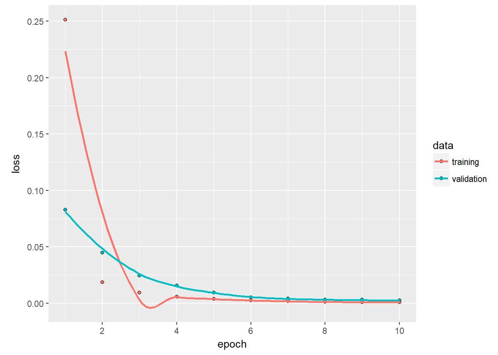

```r
history <- model %>% fit(x_trn_tr,y_trn_tr,  # x_trn_tr must be as.matrix
                         epochs=10, batch_size=4, validation_split=0.3)
plot(history)
```

```r
#--- unsale andm test if it unscaled properly --
trn_unscaled <-
  trn[,4]*attr(trn, 'scaled:scale')[4] + attr(trn, 'scaled:center')[4]
cat("test for scale-back-transformation", all.equal(df_data[,4],trn_unscaled),"\n")
```

```
## test for scale-back-transformation TRUE
```

```r
head(data.frame(df_data[,4],trn_unscaled),6)
```

| df_data...4. | trn_unscaled |
| --- | --- |
| 11.9 | 11.9 |
| 9.4 | 9.4 |
| 9.0 | 9.0 |
| 9.2 | 9.2 |
| 6.5 | 6.5 |
| 4.7 | 4.7 |

```r
#--- predict the response, unscale and calculated mean squared error
y_prd <- model %>% predict(x_trn_te)
y_prd_unscaled <-
  y_prd*attr(trn, 'scaled:scale')[4] + attr(trn, 'scaled:center')[4]


y_true <- df_data[idx==2,4]
mse_te <- sqrt(sum(y_true- y_prd_unscaled)^2)/length(y_true)
cat("mse for the test set is: ", mse_te, "\n")
```

```
## mse for the test set is:  0.4744836
```

```r
head(data.frame(y_true,y_prd_unscaled))
```

| y_true | y_prd_unscaled |
| --- | --- |
| 11.9 | 12.005595 |
| 9.4 | 9.588323 |
| 9.0 | 8.742989 |
| 9.2 | 9.165188 |
| 2.3 | 2.930457 |
| 1.7 | 1.781202 |

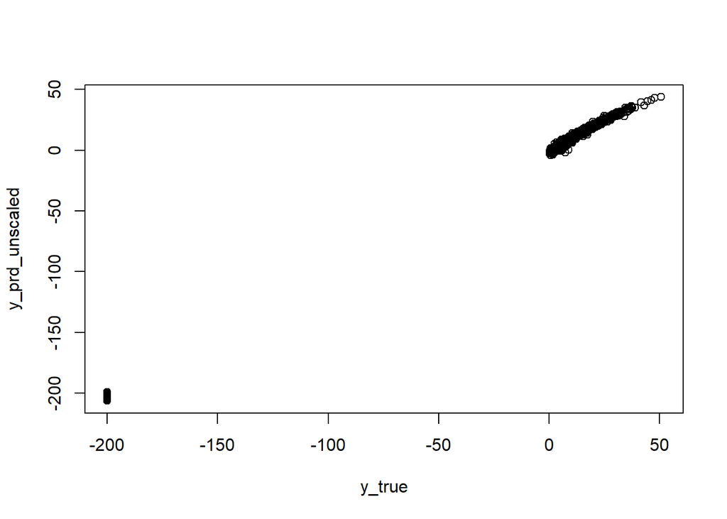

```r
mfrow=c(2, 2)
plot(data.frame(y_true,y_prd_unscaled))
```

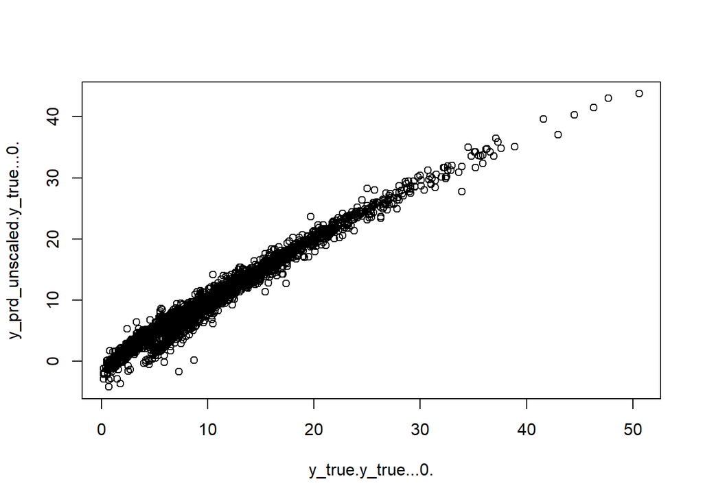

```r
plot(data.frame(y_true[y_true>0],y_prd_unscaled[y_true>0]))
```

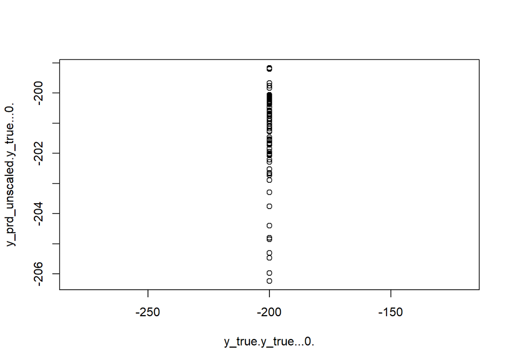

```r
plot(data.frame(y_true[y_true<0],y_prd_unscaled[y_true<0]))
```

```r
mfrow=c(1, 1)
```

# 4 Summary

# 5 Next Steps

We can gain further insight by changing the hidden layer - changing the number of neurons, or adding another layer of hidden layers, chaning optimizers.